# Normalization of the Data

Kacper Kaszuba

2024-09-16

# Uploading imputed data

```r
total <- read.csv('LFQ_imp_total.csv')
lfq_total <- total$LFQvalue # extracting the LFQ values
lfq_total.selected <- lfq_total[total$rep %in% c(22,23,24)]

mito <- read.csv('LFQ_imp_mito.csv')
lfq_mito <- mito$LFQvalue
lfq_mito.selected <- lfq_mito[mito$rep %in% c(22,23,24)]
```

**HISTOGRAM OF IMPUTED DATA**

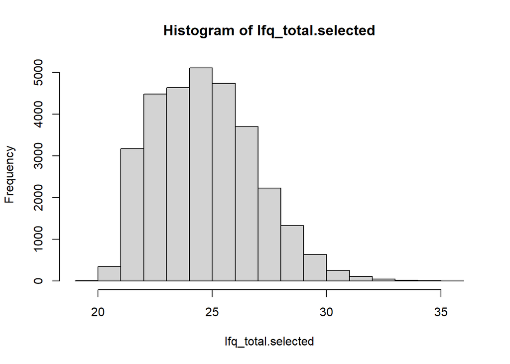

```r
hist(lfq_total.selected)
```

**BOXPLOT OF A IMPUTED DATA**

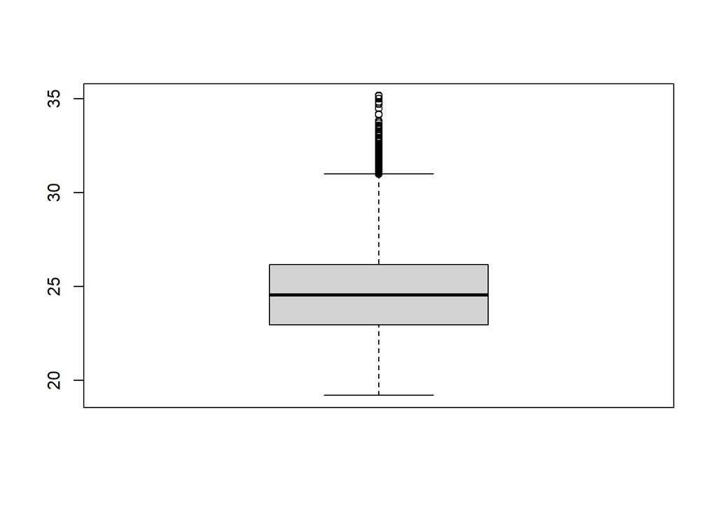

```r
boxplot(lfq_total.selected)
```

```r
# calculating skewness of the data
moments::skewness(lfq_total.selected)
```

```
## [1] 0.5035105
```

The histogram tells us that the data is slightly skewed to the right. The skewness value is higher than 0, so we should transform the data according to the image below.

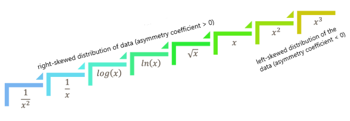

# Transformations

## Natural Log

```r
# Natural logarithm of the data
lfq_total.log <- log(lfq_total.selected)
```

**HISTOGRAM OF DATA TRANSFORMED BY LOGARITHM**

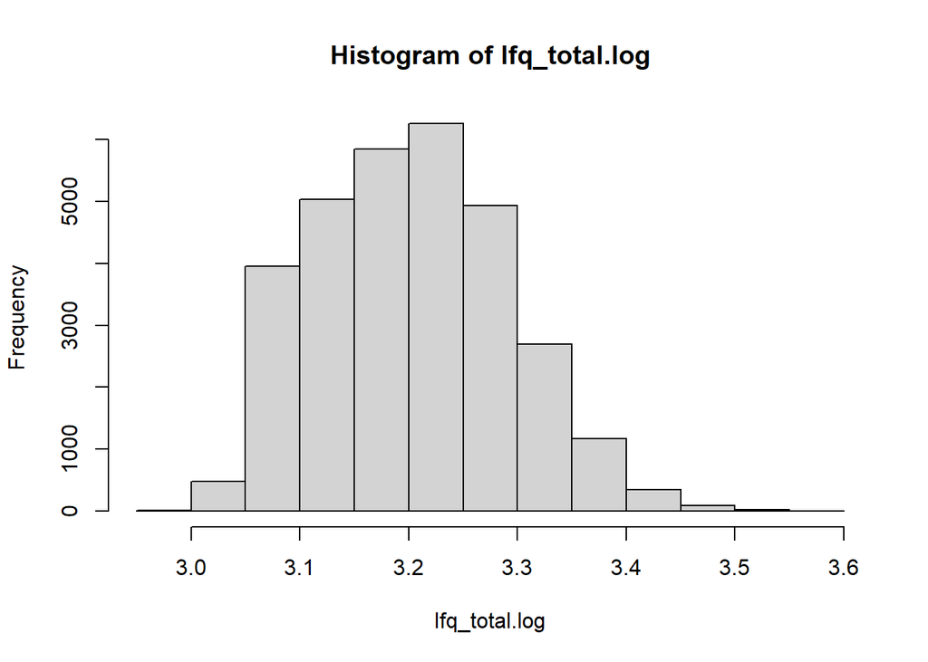

```r
hist(lfq_total.log)
```

```r
# calculating skewness of the data
moments::skewness(lfq_total.log)
```

```
## [1] 0.2888619
```

Now is better but we can make it closer to the normal distribution by calculating the fraction of $\frac{1}{x}$.

## Fraction

```r
# fraction 1/x of the data
lfq_total.frac <- 1/lfq_total.selected
```

**HISTOGRAM OF DATA TRANSFORMED BY FRACTION** $\frac{1}{x}$

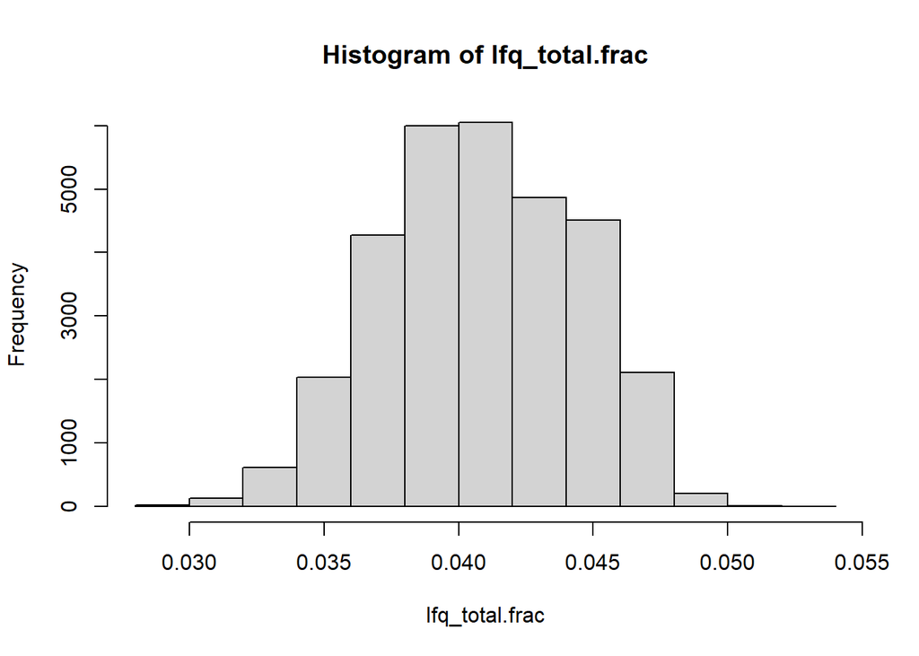

```r
hist(lfq_total.frac)
```

```r
# calculating skewness of the data
moments::skewness(lfq_total.frac)
```

```
## [1] -0.09300286
```

Now we have data that is closest to a normal distribution.

## Standardization

Formula: $\tilde{y}_{ij} = \frac{y_ij - \bar{y_j}}{\theta_j}$, where:

- $y_ij$ - value of the LFQ;
- $\bar{y_j}$ - mean of the LFQ values;
- $\theta_j$ - standard deviation of the LFQ values.

**HISTOGRAM OF THE STANDARDIZATIONED DATA**

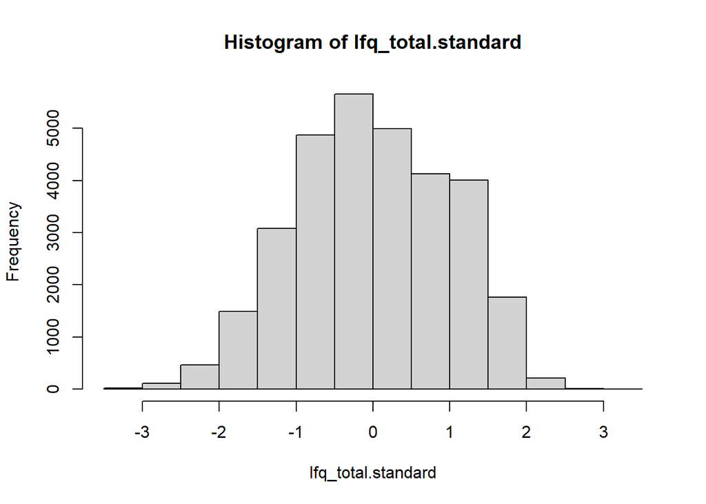

```r
lfq_total.standard <- scale(lfq_total.frac)
hist(lfq_total.standard)
```

I performed standardization on data transformed by fraction and get data with mean equals to 0 and standard deviation equals to 1.

## Linear Regression Normalization

```r
# Preprocessing of the data
lfq_total.df <- as.data.frame(lfq_total.selected)
lfq_total.df$rep <- total[total$rep %in% c(22,23,24), 'rep']
lfq_total.df$med_sample <- sapply(1:nrow(lfq_total.df), function(i) transform_M(i, lfq_total.df))
colnames(lfq_total.df) <- c('lfq_value', 'rep', 'med_sample')
```

```r
library(MASS)

# Normalization
model <- rlm(lfq_value ~ med_sample, data=lfq_total.df)
lfq_total.df$norm_lfq <- model$residuals
```

**HISTOGRAM OF THE NORMALIZED DATA BY LINEAR REGRESSION**

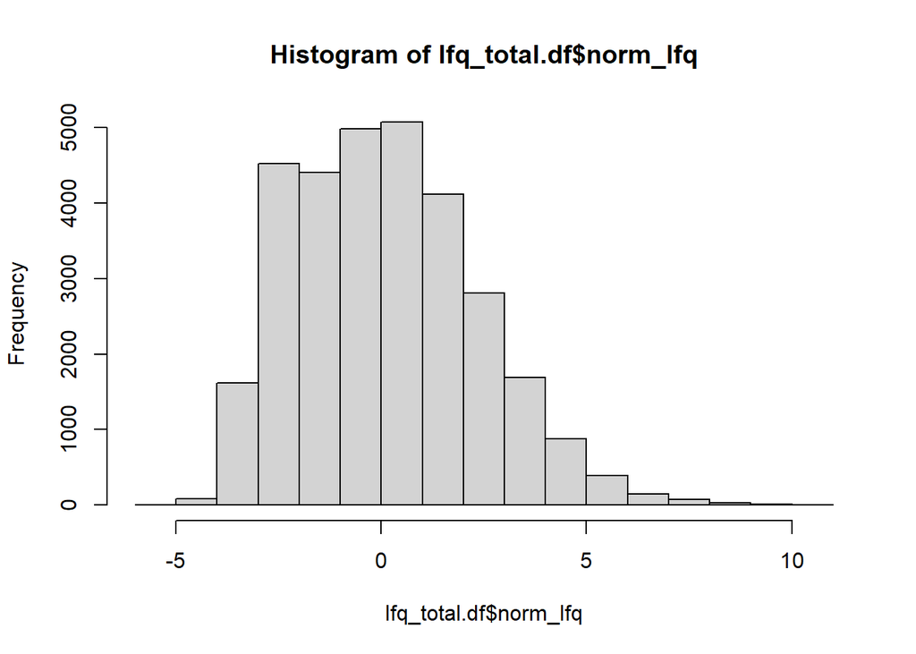

```r
hist(lfq_total.df$norm_lfq)
```

## Local regression normalization

```r
library(limma)

lfq_total.reg <- normalizeCyclicLoess(cbind(lfq_total.selected, lfq_mito.selected))[,1]
```

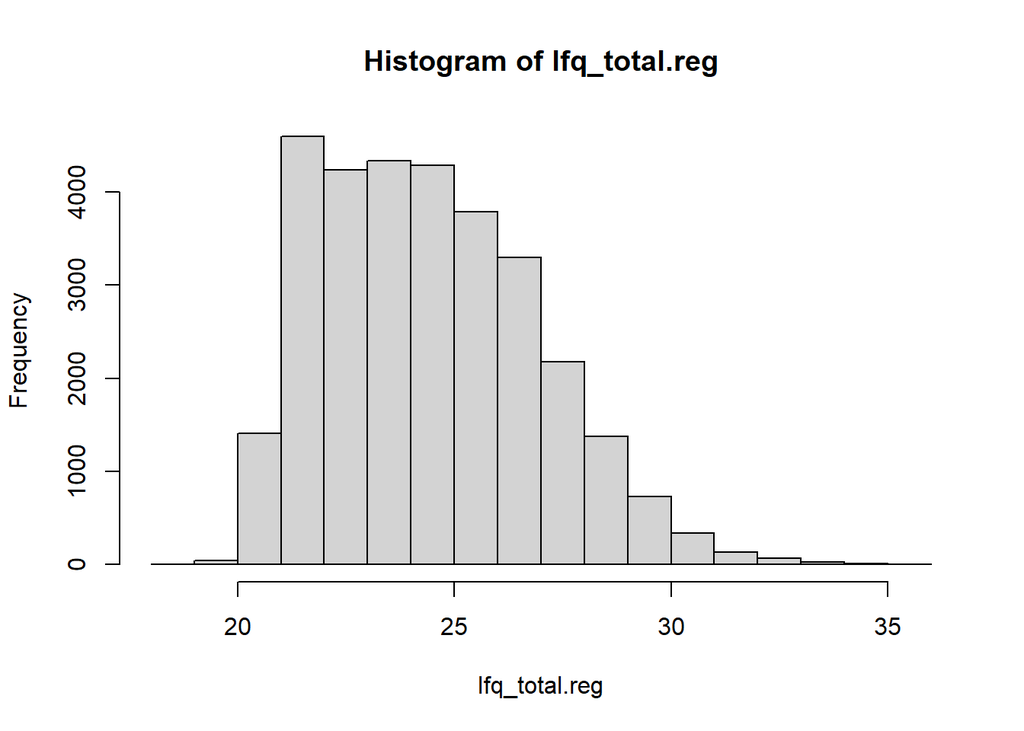

```r
hist(lfq_total.reg)
```

```r
moments::skewness(lfq_total.reg)
```

```
## [1] 0.5181988
```

## Variance stabilization normalization

```r
library(vsn)

# create input to the justvsn fxn
df <- total[total$rep %in% c(22,23,24), c('LFQvalue', 'Sample')]
df <- data.frame('KO_TOTALS_22'= df[df$Sample == 'KO_TOTALS_22', 'LFQvalue'],
                 'KO_TOTALS_23'= df[df$Sample == 'KO_TOTALS_23', 'LFQvalue'],
                 'KO_TOTALS_24'= df[df$Sample == 'KO_TOTALS_24', 'LFQvalue'],
                 'WT_TOTALS_22'= df[df$Sample == 'WT_TOTALS_22', 'LFQvalue'],
                 'WT_TOTALS_23'= df[df$Sample == 'WT_TOTALS_23', 'LFQvalue'],
                 'WT_TOTALS_24'= df[df$Sample == 'WT_TOTALS_24', 'LFQvalue'])

# check which row is which type
all_ko <- cbind(df[,1], df[,2], df[,3])
colnames(all_ko) <- c('KO_TOTALS_22', 'KO_TOTALS_23', 'KO_TOTALS_24')
all_wt <- cbind(df[,4], df[,5], df[,6])
colnames(all_wt) <- c('WT_TOTALS_22', 'WT_TOTALS_23', 'WT_TOTALS_24')

lfq_total.RG <- new('RGList', list(
    R = all_ko,
    G = all_wt))

lfq_total.vsn <- justvsn(lfq_total.RG)
```

After the VSN normalization we can create a histogram of our LFQ Values.

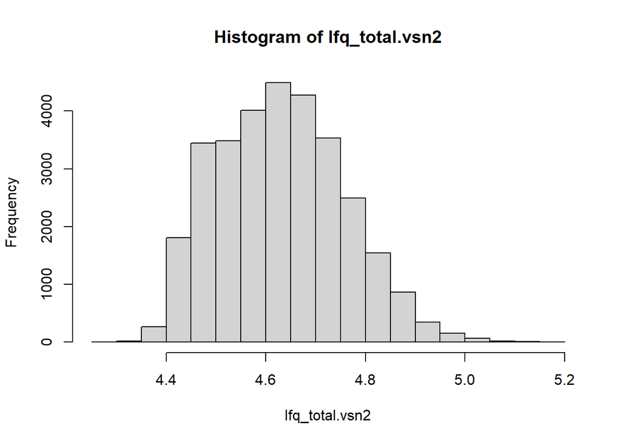

```r
lfq_total.vsn2 <- c(lfq_total.vsn@assayData[["R"]][,1],
                   lfq_total.vsn@assayData[["R"]][,2],
                   lfq_total.vsn@assayData[["R"]][,3],
                   lfq_total.vsn@assayData[["G"]][,1],
                   lfq_total.vsn@assayData[["G"]][,2],
                   lfq_total.vsn@assayData[["G"]][,3])

hist(lfq_total.vsn2)
```

## Quantile normalization

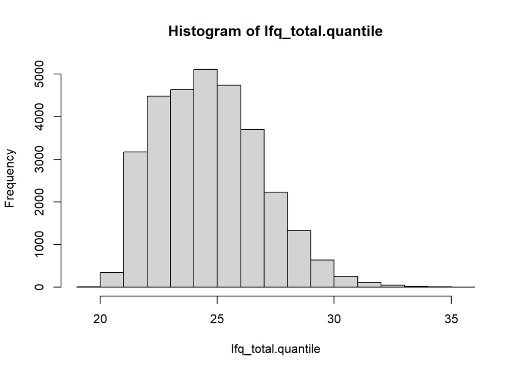

```r
library(preprocessCore)

lfq_total.quantile <- normalizeQuantiles(as.matrix(lfq_total.selected))
hist(lfq_total.quantile)
```

```r
moments::skewness(lfq_total.quantile)
```

```
## [1] 0.5035105
```

# `bestNormalize` Package for Automatic Normalization

```r
bestNormalize::bestNormalize(lfq_total.df$lfq_value)
```

```
## Best Normalizing transformation with 30828 Observations
##  Estimated Normality Statistics (Pearson P / df, lower => more normal):
##  - arcsinh(x): 4.7783
##  - Box-Cox: 4.0099
##  - Center+scale: 6.3626
##  - Double Reversed Log_b(x+a): 12.4625
##  - Exp(x): 2046.069
##  - Log_b(x+a): 4.7769
##  - orderNorm (ORQ): 1.0819
##  - sqrt(x + a): 5.4952
##  - Yeo-Johnson: 3.9462
## Estimation method: Out-of-sample via CV with 10 folds and 5 repeats
##
## Based off these, bestNormalize chose:
## orderNorm Transformation with 30828 nonmissing obs and ties
##  - 28368 unique values
##  - Original quantiles:
##     0%    25%    50%    75%   100%
## 19.184 22.933 24.549 26.154 35.164
```

Based on the output we should use the Ordered Quantile technique. Let’s check a histogram of the transformed data by this technique.

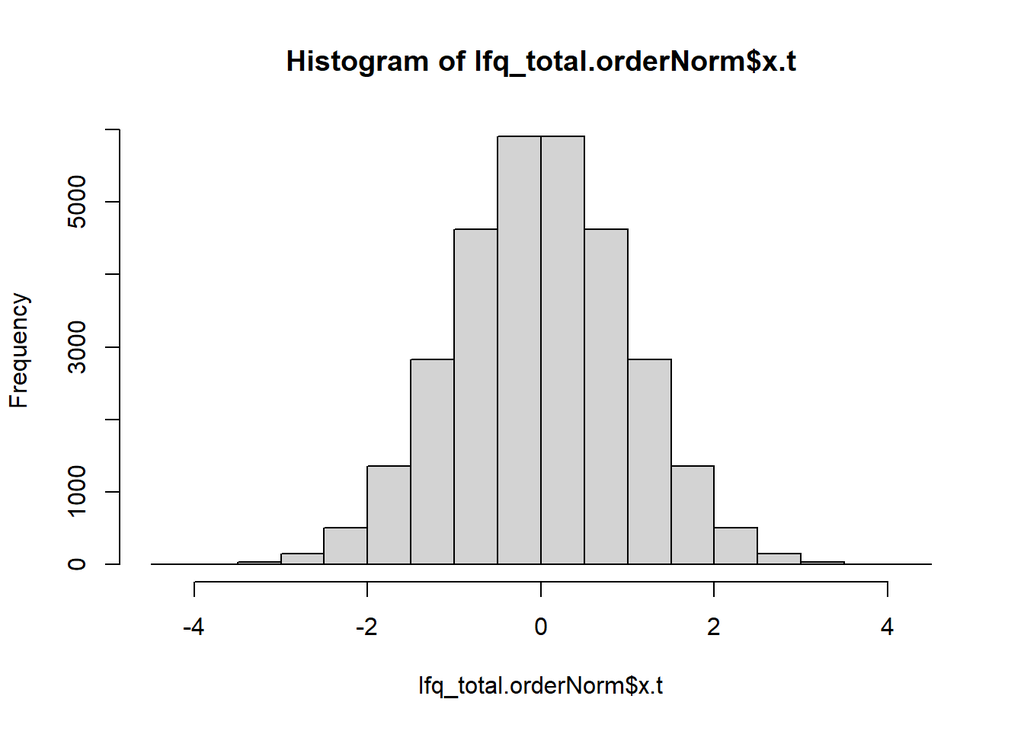

```r
bestNormalize::orderNorm(lfq_total.df$lfq_value) -> lfq_total.orderNorm
hist(lfq_total.orderNorm$x.t)
```

With this technique we have the perfect shape of the histogram.

# Comparison

We have biological data, so we want to do normalization which doesn’t miss maintain differences between biological groups, such as control vs. treated samples.

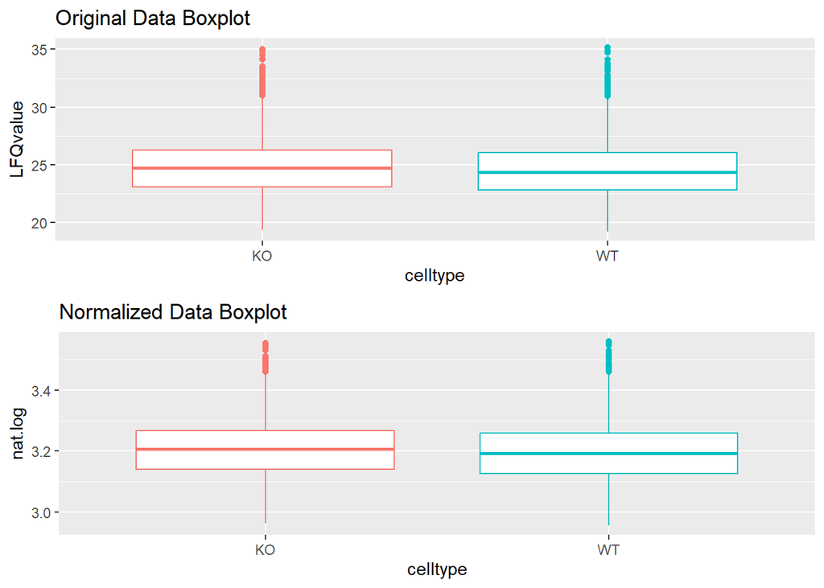

```r
plotdata(df_all, "nat.log")
```

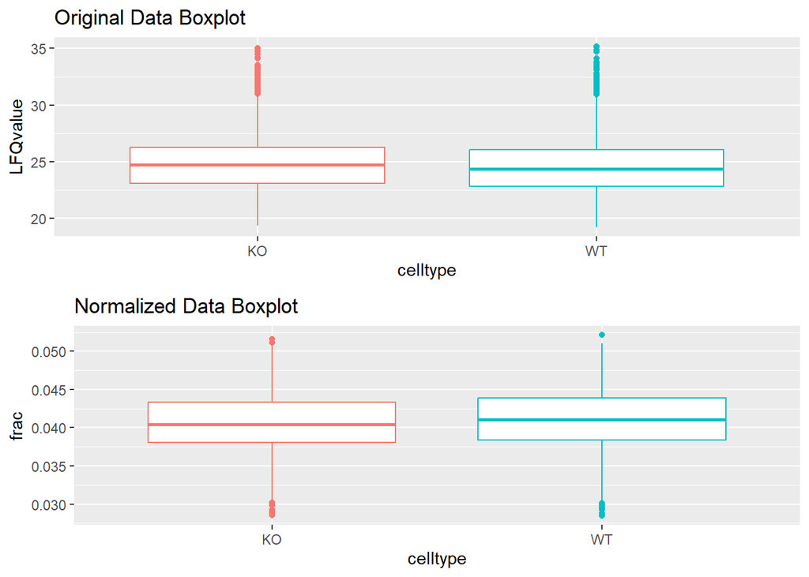

```r
plotdata(df_all, "frac")
```

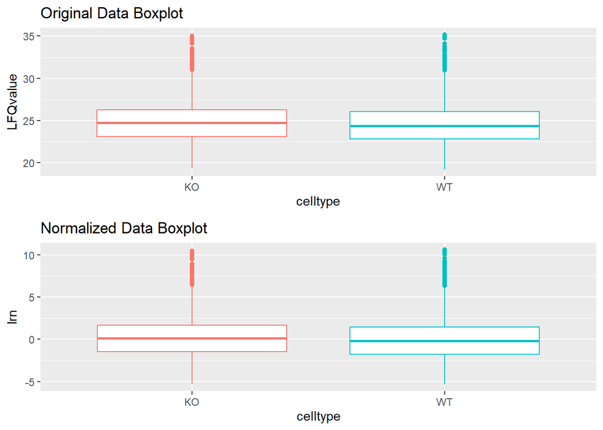

```r
plotdata(df_all, "lrn")
```

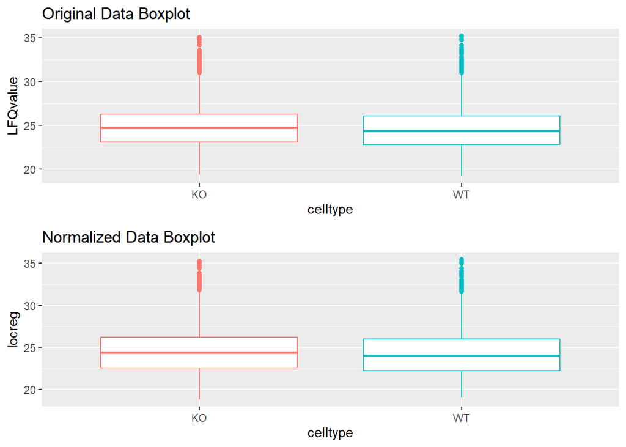

```r
plotdata(df_all, "locreg")
```

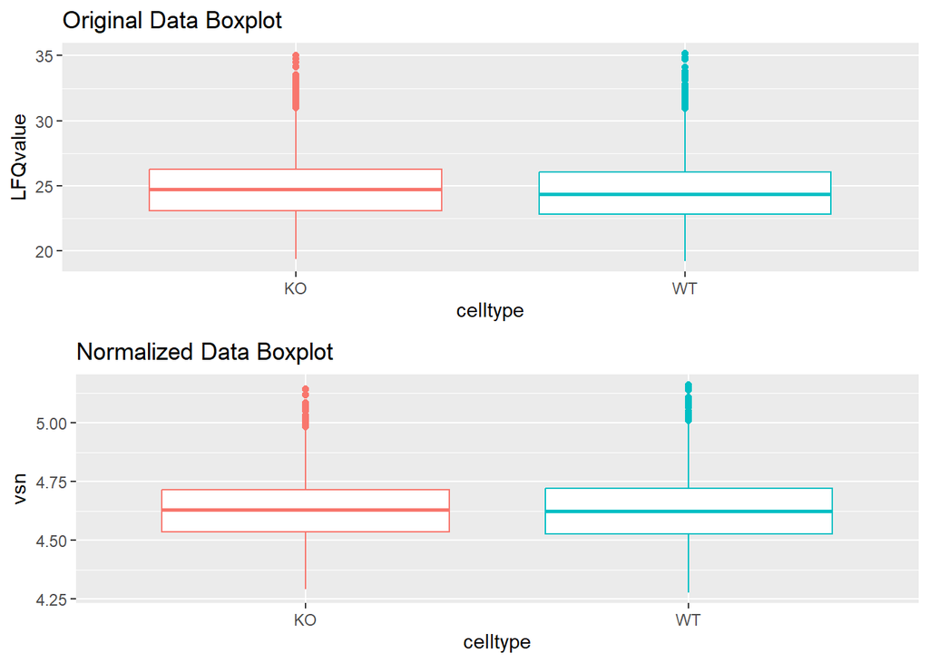

```r
plotdata(df_all, 'vsn')
```

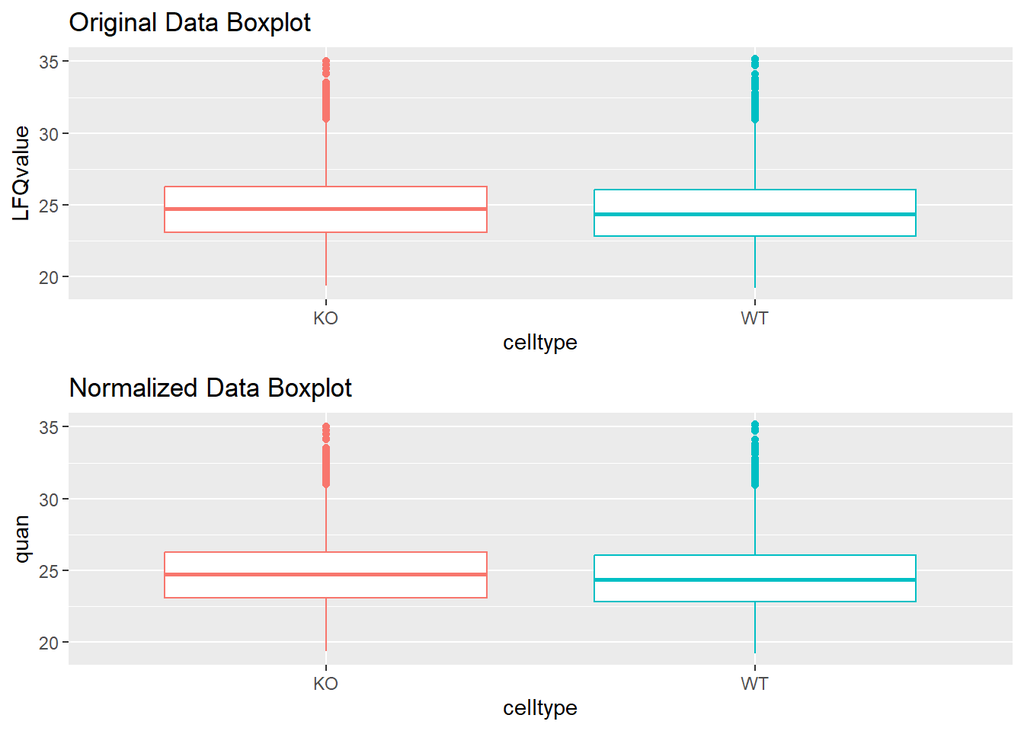

```r
plotdata(df_all, 'quan')
```

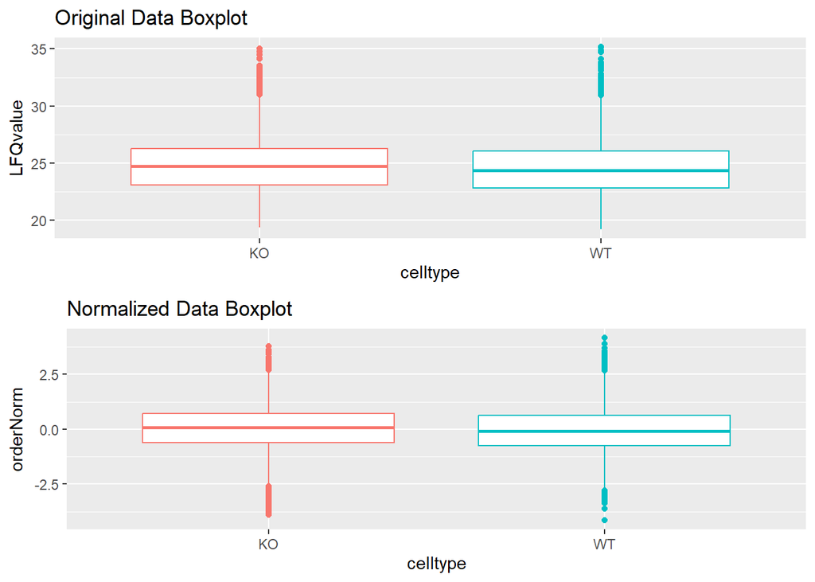

```r
plotdata(df_all, 'orderNorm')
```

Pakiety, które można wykorzystać:

- `MASS` - Linear regression normalization (Rlr, RlrMA, RlrMACyc)
- `limma` - Local regression normalization (LoessF, LoessCyc), function: `normalizeCyclicLoess`
- `vsn` - Variance stabilization normalization, function: `justvsn`
- `preprocessCore` - Quantile normalization, function: `normalize.quantiles`
- Median normalization - trzeba znaleźć albo napisać funkcję
- Progenesis normalization - Progenesis data analysis software
- EigenMS normalization: http://sourceforge.net/projects/eigenms/

# References

1. [A systematic evaluation of normalization methods in quantitative label-free proteomics](https://academic.oup.com/bib/article/19/1/1/2562889)
2. [bestNormalize R Package](https://cran.r-project.org/web/packages/bestNormalize/vignettes/bestNormalize.html#the-ordered-quantile-technique)